# State of Salmon: Technical Documentation

Pacific Salmon Foundation

Version 1.0 (2024-May-07)

DRAFT

# About the Report

The State of Salmon Report 2024 is a broad-scale evaluation of the state of all six species of Pacific salmon found in British Columbia and the Yukon, Canada. This flagship publication from the [Pacific Salmon Foundation](https://www.psf.ca) takes a data-driven approach to summarizing the status and trends in regional abundance for each species of salmon in nine major salmon-bearing regions in western Canada. The report also identifies key factors that are influencing salmon abundance and identifies ways in which society can contribute to salmon recovery and resilience.

## Why PSF?

The Pacific Salmon Foundation, founded in 1987, is a non-profit environmental organization dedicated to making transformational change for the benefit of Pacific salmon at every scale – from the smallest streams to the open ocean. We work with First Nations, Government, ENGO partners, industry, and all salmon supporters to achieve our vision of healthy, sustainable, and naturally diverse populations of Pacific salmon for the benefit of ecosystems and people for generations to come. By bringing together diverse representatives, we embolden big ideas and support long-term positive changes for salmon. We operate at the nexus of science and action, and this is where the State of Salmon Report fits in: raising public awareness and political will for salmon to influence evidence-based decision making.

Our approach to assessing the State of Salmon is based in Western science and offers a data-driven perspective on broad-scale status and trends. For many regions and species, the scientific record is relatively short and may not adequately represent changes in abundance that have undoubtedly occurred over centuries of colonization, settlement, and human development. However, these data represent a type of information that can be relatively easily compiled, analysed, and compared across broad spatial scales. We encourage readers to seek out additional sources of information about salmon in their area, in particular from local First Nations who often have deep intergenerational knowledge and relationships with salmon.

## Technical Documentation

This Technical Documentation augments the high-level description of Methods on the State of Salmon site and provides detailed information on the data sources and methods used to assess the State of Salmon. The suggested citation for this Technical Documentation is:

> Pacific Salmon Foundation. 2024. The State of Salmon Report 2024: Technical Documentation. Version 1.0. Available online at https://bookdown.org/salmonwatersheds/state-of-salmon/methods [accessed dd-mm-yyyy].

## More Information

Code and raw data are available in the state-of-salmon GitHub repository. Compiled data and output summary statistics on status and trends for each region and species are availabel for download in the Salmon Watershed Program’s [Data Library](https://data.salmonwatersheds.ca/).

Questions regarding data sources, analysis, and code can be directed to Stephanie Peacock (speacock@psf.ca).

# Methods

## General Approach

We report spawner abundance for each of nine regions that represent all major Pacific salmon-bearing watersheds in Canada: Yukon, Transboundary, Haida Gwaii, Nass, Skeena, Central Coast, Vancouver Island & Mainland Inlets, Fraser, and Columbia. These regions are also used to organize data in the [Pacific Salmon Explorer](https://www.salmonexplorer.ca). There are a relatively small number of Pacific salmon that spawn in the MacKenzie River basin in Arctic Canada that are currently not considered here.

We separate five species of Pacific salmon: Chinook, chum, coho, pink, and sockeye. We also report status of steelhead trout for regions where spawner data are are available and can reasonably be expanded to yield an estimate of regional abundance (Nass, Skeena, interior Fraser, and Columbia). When assessing biological status, pink salmon are often separated into even- and odd-year lineages due to their consistent 2-year life cycle. However, for the general overviews provided in State of Salmon we consider generational averages, which take the running average of even- and odd-year lineages for pink salmon. This approach of using generation running averages also smooths over dominant years for sockeye salmon, for which many populations display cyclic dominance. Shifts in dominance between even- and odd-year pink populations or declines in sub-dominant years of sockeye salmon are considered in a more nuanced way in our reporting when discussing how changes in abundance have been reflected in the diversity and distribution of each species within the region.

For each of these species, where data are available, we construct an index of **spawners** at the regional scale. We focus on spawner abundance because these data are more readily accessible and easily summarised at different spatial scales. Spawners represent the abundance of salmon available to reproduce and contribute to future generations, as well as to meet cultural and ecological needs within watersheds, and thus provides a measure of status relevant to communities and ecosystems. We recognize that commercial catch has historically been a substantial portion of salmon that return to the coast, and that ignoring declines in catch will underestimate the declines in overall salmon abundance. Therefore, we include information on **returns** (i.e. spawners plus catch) for species and regions with reliable data.

We have strived to base our assessments on the best available data for each region and species. For example, stocks that are governed by international treaties may be monitored by the [Pacific Salmon Commission (PSC)](https://www.psc.org/), and tend to have reliable time series of abundance available at regional scales. These data sources are outlined in the Region-Specific Data section. For species and regions where aggregate abundance is not reported by the PSC or DFO at the scale needed, we adapted our approach to make the best use of available data. In most cases, this meant expanding spawner abundance from stream-level estimates to get a regional scale index of spawner abundance using two types of expansion factors (English et al. 2016). This expansion process is described in the Expansion Factors section.

## Region-Specific Data Sources

Here we describe specific data sources for the abundance of salmon and steelhead at the regional scale.

### Yukon

The Canadian portion of the Yukon River is home to Chinook, chum, and coho salmon. Border escapement and total return of Canadian-origin Chinook and fall chum salmon in the mainstem Yukon River are counted at the Eagle Sonar station on the Yukon/Alaska border, and are available from the [Yukon River Panel](https://www.yukonriverpanel.com/) in their Joint Technical Committee (JTC) Reports. Specifically, we used Chinook `Spawning escapement estimate` and `Canadian origin total run size estimate` from Appendix B11 of JTC (2023). Chum salmon spawner data were from Appendix B16 and total return from Appendix B20 of JTC (2023). Estimates from 2023 have not yet been published but were reported in the January 2024 post-season Yukon River Panel meeting (recording available on the YRP website [here](https://www.yukonriverpanel.com/meetings/past-meetings/)), and should be considered preliminary.

There are also Chinook, chum, and coho salmon in the Canadian portion of the Porcupine River, which joins the mainstem Yukon River in Alaska. Data on escapement to the Porcupine River are more patchy and not currently included here.

### Transboundary

Pink and chum salmon are less extensively monitored in the Transboundary, with ongoing escapement available only from the Canyon Island fish wheel on the Taku River. We used the index of escapement from the Canyon Island fish wheel as an index of regional spawner abundance for pink and chum (Transboundary Technical Committee 2022). There are some historical data for pink salmon spawner abundance in the Nakina River of the Taku watershed, but this location has not reported data since 1998 and thus we did not include this stream survey in our index of regional abundance.

Steelhead trout have also been enumerated at the Canyon Island fish wheel since 1987, though recent estimates have been patchy and the timing of the fish wheel likely misses a substantial portion of the Taku summer run steelhead. Thus, we do not use the Canyon Island counts as an index of steelhead abundance.

We recognize that our approach in the Transboundary lacks information from many un-monitored watersheds, in particular the smaller watersheds of the Chilkat, Unuk, and Whiting Rivers. In the absence of better monitoring, we choose to report available data as a proxy for regional abundance, and note that the contribution of these smaller watersheds to total regional abundance for each species is likely small.

### Haida Gwaii

For Haida Gwaii, we followed the Expansion Factors approach described below, with the exception of Chinook salmon for which the only data are from a single enumeration project on the Yakoun River. We show Yakoun River spawner abundance up to 2006, but no estimates were available for the most recent generation making the current status for Haida Gwaii Chinook “Unknown”. For other species, we compared our expansion approach to estimates of escapement to Area 1 reported in the TCNB (2023) (Appendix 30) but found the Area 1 estimates were much lower (except for Chinook, for which Appendix 30 matched the Yakoun River estimates exactly).

### Nass

Chinook spawners and total return were taken from the [PSC’s Chinook Technical Committee (CTC) data sets](https://www.psc.org/publications/technical-reports/technical-committee-reports/chinook/ctc-data-sets/) and are reported on in CTC (2023). Specifically, Nass River (Area 3) escapement and terminal run are provided in Table B3 (fields `Esc` and `t.run` respectively).

Chum and pink salmon were expanded from available spawner surveys, as described below in Expansion Factors. Note that the designation of indicator streams for the Nass region was based on English et al. (2018) rather than the indicator designation in NuSEDS.

Nass coho escapement and total return were reconstructed by English et al. (2023) for each of the three coho Conservation Units in the Nass region for 1992-2022. We summed the total escapement (`TE`) and total return (`Total Run`) across these three Conservation Units to yield the regional aggregate abundance.

Nass sockeye escapement and total return were derived from the Northern Boundary Sockeye Run Reconstruction (NBSRR) Model that estimates total escapement and total return for the Skeena and Nass Rivers (English et al. 2004; English et al. 2017). Specifically, we used fields `TE` (Total Escapement) and `Total run` for Area 3 sockeye from the 2022 update to the North and Central Coast (NCC) Salmon Database Version 2, maintained by LGL Ltd. with support from PSF (English et al. 2016; Challenger et al. 2018; English et al. 2018).

The index of Nass steelhead spawner abundance and total return are for the Nass Summer CU, developed in collaboration with the Nisga’a Fish and Wildlife Department and LGL Ltd. (English et al. 2023). There is another steelhead CU in the Nass region - Nass Winter - which is not well monitored and therefore not included in our index of spawner abundance.

### Skeena

Chinook spawners were taken from the [PSC’s Chinook Technical Committee (CTC) data sets](https://www.psc.org/publications/technical-reports/technical-committee-reports/chinook/ctc-data-sets/) and are reported on in CTC (2023). Specifically, Skeena River (Area 4) escapement is provided in Table B3 (field `Total Esc`). There is no total return for the Skeena River provided in the CTC data sets.

For Skeena chum salmon, we used escapement to Area 4 reported in Table 32 of TCNB (2023) rather than expanding escapement from spawner surveys because surveys of indicator stream have been increasingly patchy over the last 30 years, making expansions uncertain.

Skeena coho and pink salmon were expanded from available spawner surveys, as described below in Expansion Factors. Note that the designation of indicator streams for the Skeena region was based on English et al. (2018) rather than the indicator designation in NuSEDS.

Skeena sockeye escapement and total return were derived from the Northern Boundary Sockeye Run Reconstruction (NBSRR) Model that estimates total escapement and total return for the Skeena and Nass Rivers (English et al. 2004; English et al. 2017). Specifically, we used fields `TE` (Total Escapement) and `Total run` for Area 4 sockeye from the 2022 update to the North and Central Coast (NCC) Salmon Database Version 2, maintained by LGL Ltd. with support from PSF (English et al. 2016; Challenger et al. 2018; English et al. 2018).

The index of Skeena steelhead spawner abundance is derived from estimated escapement of Skeena Summer steelhead at the Tyee Test Fishery (1956 - present), provided by the Province via email. As for other regions, these estimates may not capture winter-run steelhead, for which data are not available.

### Central coast

Estimates of spawner abundance for all salmon species on the Central Coast were expanded from available spawner surveys, as described below in Expansion Factors. Note that the designation of indicator streams for the Central Coast region was based on English et al. (2018) rather than the indicator designation in NuSEDS.

There are two spawner surveys for Steelhead trout on the Central Coast that we report in the Pacific Salmon Explorer. However, these surveys have been patchy through time with the most recent estimates from 2016. Therefore, spawner abundance and total return for Central Coast steelhead was considered unknown.

### Fraser

Escapement of Fraser Chinook is provided in the [PSC’s Chinook Technical Committee (CTC) data sets](https://www.psc.org/publications/technical-reports/technical-committee-reports/chinook/ctc-data-sets/) and are reported on in CTC (2023). We took the sum of escapement to indicator stocks in Table B6 (all Spring/Summer, Harrison, Lower Shuswap, Nicola, Lower Chilcotin, and Chilko) as an index of spawner abundance. Catch of Fraser Chinook is provided in Table A14 but cannot be directly added to indicator escapement to yield total return. PSF is pursuing Chinook run reconstruction output for the Fraser to inform total return.

Fraser chum catch and escapement are reported by PSC’s Chum Technical Committee (TTCHUM 2023), however the most recently published report only contains estimates for 2010-2019 and the data were not otherwise made available to us. As such, we estimated spawner abundance from available spawner surveys in NuSEDS as described below in Expansion Factors. We note that, although most NuSEDS data was updated to include surveys in 2022, for Fraser chum the most recent data was from 2020.

For interior Fraser coho CUs, spawner abundance and total return were provided by DFO on data request (pers. comm. Marissa Glavas, Data Manager, Fraser River Stock Assessment). The Fraser coho estimates of spawners and returns are based on Interior Fraser coho that spawn upstream of Hells Gate in BC (including five CUs: Fraser Canyon, Interior/Middle Fraser, Lower Thomposn, South Thompson, and North Thompson). We report total return as the sum of “Total Pre-Fishery Abundance” to all CUs and spawner abundance as the sum of “Total Return” (i.e., final spawner estimate plus fish removed from the system by DFO Salmon Enhancement Program or First Nations) to all CUs (we note the term “total return” is used differently in this data set to represent spawners). We recognize that using these estimates ignores coastal coho populations, for which monitoring has been patchy through time.

Data on total return and spawner abundance of pink salmon and sockeye salmon in the Fraser region are provided by the PSC and accessed through the Fraser Panel Annual Report: Data Application (Pacific Salmon Commission 2024). Total escapement for Fraser sockeye was not yet available for 2023, and 2023 total return is considered preliminary. We note that Fraser River pink salmon are only counted in the dominant, odd-year run.

Steelhead trout in the Fraser are monitored by the Province in at least 10 different streams, but these data are not readily available. Relatively reliable estimates of steelhead spawner abundance are available at the CU-level for interior Fraser steelhead from the Thompson Summer CU (monitored at the Thompson River) and Mid Fraser Summer CU (primarily monitored at the Chilcotin River; data in the [Pacific Salmon Explorer](https://salmonexplorer.ca)). We used the sum of CU-level spawner abundance for these two CUs as an index of Fraser steelhead abundance. We note that this approach does not include more coastal populations, such as the Lower Fraser Summer steelhead monitored in the Coquihalla River or Boundary Bay Winter steelhead, which may not have declined to the same extent over the past decade. However, a lack of publicly accessible data on coastal Fraser steelhead has limited our ability to include these CUs in our index of abundance.

### Columbia

We used CU-level estimates of spawner abundance (run reconstructions) sourced from DFO (Ogden, pers. comm.) for Chinook and Stockwell and Hyatt (2003) and subsequent updates for sockeye.

There is no monitoring of steelhead trout in the Canadian portion of the Columbia region, but the Okanagan Nation Alliance does enumerate steelhead in akskwəkwant (Inkaneep Creek) and estimate a Canadian portion of steelhead spawning abundance. These data can be found in associated report (e.g. OBMEP (2022)) and are available in the Pacific Salmon Explorer as the CU-level spawner abundance for the Mid Columbia Summer CU.

## Expansion Factors

For species and regions that lacked reliable data on spawner abundance and total return at the appropriate scale, we estimated regional-scale abundance from stream-level surveys. We started with spawner survey data shown in the [Pacific Salmon Explorer](https://www.salmonexplorer.ca). Spawner surveys were each assigned to one of the nine regions we considered based on their geographic location. We note that this is slightly different from how spawner survey data are organized in the Pacific Salmon Explorer, where data are organized by Conservation Units (CUs) that may span regional boundaries (e.g. for pink salmon that have relatively geographically large CUs). In cases of trans-regional CUs, the spawner surveys appear in both regions in the Pacific Salmon Explorer, whereas here we assign spawner surveys to the region in which they fall geographically, regardless of the CU boundary.

For each decade (or reference decade if insufficient information) $d$, the average number of spawners returning to indicator stream $i$ is calculated as:

$$\bar{S}_{d,i} = \sum_{y = 1}^{Y_{d,i}}
\frac{\hat{S}_{y/d, i}}{Y_{d,i}}$$
where $Y_{d,i}$ is the number of years for which spawner estimates are available within decade $d$ for stream $i$. From the average number of spawners for all indicator streams, the decadal proportional contribution of each indicator stream is calculated as:

$$P_{d,i} =
\frac{\bar{S}_{d,i}}{\sum_{i=1}^{I} \bar{S}_{d,i}}$$
where $I$ is the total number of indicator streams.

Expansion Factor 1 is then calculated for each year within the decade $y/d$ based on the decadal contributions and which streams were monitored or not in a given year:

$$F_{1,y/d}=\left( \sum_{i=1}^I P_{d,i}
w_{y/d,i} \right)$$
where $w_{y/d,i}$ is 1 if stream $i$ was monitored in year $y$ and 0 if stream $i$ was not monitored in year $y$. Expansion Factor 1 is then multiplied by the sum of the observed spawners in all indicator stream to yield the expanded estimate of spawner abundances in all indicator streams in the region:

$$S'_{y} = F_{1,y/d} \sum_{i=1}^I
\hat{S}_{y,i}$$

Expansion Factor 2 $F_{2,d}$ expands the spawner abundance to all indicator streams, $S'_{y}$, to account for non-indcator streams. Unlike Expansion Factor 1, this is calculated for each decade (rather than each year) and then applied to all years within a decade. Like Expansion Factor 1, there needs to be sufficient information within the given decade in order to calculate $F_{2,d}$, or else a reference decade is chosen. See English et al. (2016) for detailed on how reference decades are chosen in that case.

Expansion Factor 2 is calculated as:

$$F_{2,d} = \frac{\sum_{i = 1}^I
\bar{S}_{d,i} + \sum_{j = 1}^{J} \bar{S}_{d,j}}{\sum_{i = 1}^I
\bar{S}_{d,i}}$$
where $\bar{S}_{d,i}$ and $\bar{S}_{d,j}$ are the deacdal average number of spawners in indicator and non-indicator streams, respectively, calculated above. $J$ is the total number of non-indicator streams. The adjusted total number of spawners in both indicator and non-indicator streams is then calculated as:
$$S''_{y} = F_{2,d} S'_{y}$$

Note that when expanding spawner abundance for spawner-recruit analysis, a third expansion factor is applied to account for streams that are never monitored and for observer (in)efficiency (Peacock et al. 2020). We did not apply this third expansion factor because it is highly undertain and we are interested in relative changes in abundance through time, so we do not require to expand to absolute abundance.

## Smoothing

We smoothed time series of spawner abundance and total return using a right-aligned running geometric mean over the length of a generation. This reduces the influence of dominant years and produces an index that is less sensitive to stochastic interannual variability that is common in salmon population dynamics. The generation length was based on the dominant life-history type for each species in a particular region. The smoothed spawner abundance in year $y$ given a generation length $g$ was calculated as:
$$\bar{S_{y}} = \left( \prod_{t = y-g+1}^y
{S''_t} \right)^{1/g}$$

We smoothed abundance from the first year to the most recent year of raw abundance data. If there were intermediate years with missing data, the smoothed abundance was still calculated using the available years (i.e. ignoring the missing data, with the exponent $1/g$ adjusted so that $g$ reflected the number of years with data in the generation). If all years in a generation were missing data, than the smoothed abundance was `NA`.

When plotting, we show the smoothed abundance relative to the long-term historical average, so that species that have vastly different abundances within a region can be plotted on the same y-axis for comparison.

## Quantifying change

We summarize the time series of smoothed spawner abundance or total return at the regional scale using three different metrics:

1. **Current status** relative to historical average;
2. **Long-term trend** over the entire time series; and
3. **Short-term trend** over the most recent three generations.

The currents status provides information on how the most recent spawner abundance compares to past values, while the two trend metrics provide information on the average direction of change and are less sensitive to the magnitude of current abundance.

The **current status** relative to historical average is calculated as:
$$(\bar{S_{y}} - \bf{S}) /
\bf{S}$$
where $y$ is the most recent year for which the index of spawner abundance could be calculated and $\bf{S}$ is the average smoothed spawner abundance over the entire time series.

The **long-term trend** is calculated following the recommendations of D’Eon-Eggertson et al. (2015), who found that the correct identification of declines in salmon population abundance may be most reliable when considering the entire time series, and applying regression-based estimates of change calculated from log-transformed and smoothed spawner abundances. As such, we fit a simple linear model to the time series of $\log ( \bar{S}_{y} )$ over $y$. The resulting slope, $m$, gives an average estimate of annual change:

$$m = \log \left(
\frac{\bar{S}_{y}}{\bar{S}_{y-1}} \right)$$
.

With some rearranging, we can calculate the average annual percent change as:
$$\frac{\bar{S}_{y} -
\bar{S}_{y-1}}{\bar{S}_{y-1}} = \frac{ e^m \bar{S}_{y-1} -
\bar{S}_{y-1}}{\bar{S}_{y-1}} = e^m - 1$$
. If the slope $m$ is not significantly different from zero ($p \geq 0.05$), then the trend is classified as “stable” regardless of the magnitude of the estimated slope. If the slope is significantly different from zero ($p < 0.05$), then the trend is classified as increasing if $m > 0$ or decreasing if $m < 0$.

The **short-term trend** is calculated as described above, but only using the time series over the most recent three generations.

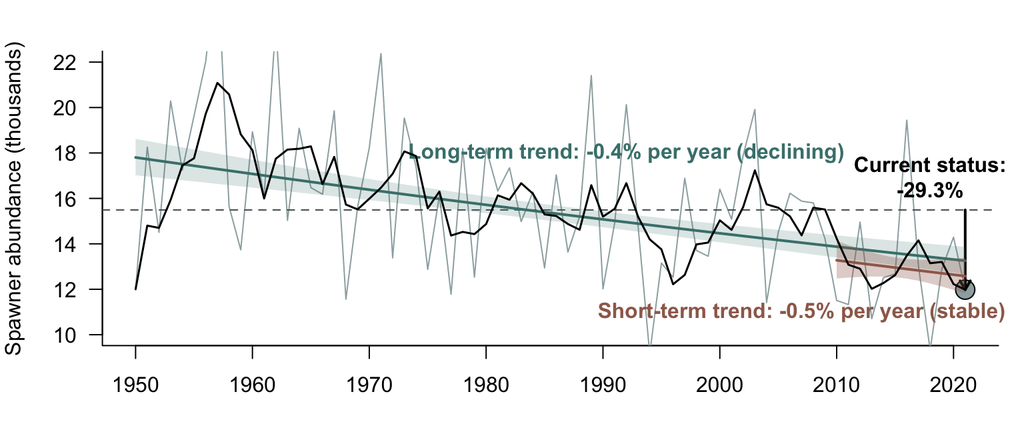

**Above:** Simulated time series of spawner abundance (grey line), smoothed with a running geometric mean over the generation length (4 years; black line). The three metrics are illustrated: **Current status** relative to historical average (black); **Long-term trend** over the entire time series (green); and **Short-term trend** over the most recent three generations (clay). The shaded regions of the regression lines indicate the 95% prediction intervals. In this example, the short-term trend is not statistically significant (p > 0.05), and so the trend is characterized as ‘stable’ despite the negative slope.

### Additional Considerations

The standardized approach to quantifying change described above was applied across regions and species. We then considered two additional attributes prior to reporting on the State of Salmon:

1. If the species and region had no data in the most recent generation, the current status was “Unknown” even if historical abundance information was available. This was the case for **Haida Gwaii Chinook**, for which there were no reliable estimates of spawners since 2006.
2. If the time series of abundance (spawners or total return) contained fewer than 20 years of data, we could not reliably establish a historical baseline and the current status was therefore “Unknown”. This applied to **Columbia Chinook** and **Columbia steelhead**, both of which have been monitored since 2006.

# References

Challenger, W., Mochizuki, T., English, K., and Bychkov, Y. 2018. North and Central Coast Salmon Database and Analysis System User Manual. LGL Limited for Pacific Salmon Foundation, Sidney, BC.

CTC. 2023. Annual Report of Catch and Escapement for 2022. Pacific Salmon Commission Joint Chinook Technical Committtee Report **TCCHINOOK (23)-02**: xiii + 202 p. Available from https://www.psc.org/publications/technical-reports/technical-committee-reports/chinook/.

D’Eon-Eggertson, F., Dulvy, N.K., and Peterman, R.M. 2015. Reliable Identification of Declining Populations in an Uncertain World. Conservation Letters **8**(2): 86–96. doi:10.1111/conl.12123.

English, K.K., Alexander, R.F., Ian A. Beveridge, Challenger, W., Percival, N., Hertz, E., and Atkinson, C. 2023. Preliminary Area 3 Salmon (2018–2022) and Nass River Summer-Run Steelhead (1994–2022) Escapement, Catch, Run Size, and Exploitation Rate Estimates. Prepared by LGL Ltd. and Nisga’a Lisims Government - Fisheries & Wildlife Department for the Pacific Salmon Foundation and Nisga’a-Canada-BC Treaty’s Joint Fisheries Management Committee. Available from https://salmonwatersheds.ca/document/lib_526/.

English, K.K., Gazey, W.J., Peacock, D., and Oliver, G. 2004. Assessment of the Canadian and Alaskan Sockeye Stocks Harvested in the Northern Boundary Fisheries using Run Reconstruction Techniques, 1982-2001. Available from https://salmonwatersheds.ca/document/lib_a_787_06/.

English, K.K., Noble, C., and Carr-Harris, C. 2017. Skeena Sockeye In-river Run Reconstruction Analysis Model and Analysis Results for 1982-2017. Report prepared for Pacific Salmon Foundation by LGL Ltd. and Fisheries and Oceans Canada. Available from https://salmonwatersheds.ca/document/lib_452/ [accessed 23 November 2023].

English, K.K., Peacock, D., Challenger, W., and Mochizuki, T. 2016. North and Central Coast Salmon Escapement, Catch, Run Size and Exploitation Rate Estimates for each Salmon Conservation Unit for 1954-2014. (November): 102.

English, K.K., Peacock, D., Challenger, W., Noble, C., Beveridge, I., Robichaud, D., Beach, K., Hertz, E., and Connors, K. 2018. North and Central Coast Salmon Escapement, Catch, Run Size and Exploitation Rate Estimates for each Salmon Conservation Unit for 1954-2017. Prepared by LGL Ltd. for the Pacific Salmon Foundation. 125p. Available from https://salmonwatersheds.ca/document/lib_451/.

JTC. 2023. Yukon River Salmon 2022 Season Summary and 2023 Season Outlook. Yukon River Joint Technical Committee Report **YUKON JTC (23)-01**: vi + 181 p. Available from https://www.yukonriverpanel.com/publications/yukon-river-joint-technical-committee-reports/.

OBMEP. 2022. 2021 Okanogan Subbasin Steelhead Spawning Abundance and Distribution. Okanogan Basin Monitoring and Evaluation Program. Colville Confederated Tribes Fish and Wildlife Department. Submitted to the Bonneville Power Administration., Nespelem, WA.

Pacific Salmon Commission. 2024. PSC Annual Report Application. Release 2024.04 [Updated 2024 apr 03; accessed 2024 Apr 05]. Available from https://www.psc1.shinyapps.io/PSC_Annual_Fraser/.

Peacock, S.J., Hertz, E., Holt, C.A., Connors, B., Freshwater, C., and Connors, K. 2020. Evaluating the consequences of common assumptions in run reconstructions on Pacific salmon biological status assessments. Canadian Journal of Fisheries and Aquatic Sciences **77**(12): 1904–1920. Canadian Science Publishing. doi:10.1139/CJFAS-2019-0432/ASSET/IMAGES/CJFAS-2019-0432IEQ43.GIF.

Stockwell, M.M., and Hyatt, K.D. 2003. A summary of Okanagan sockeye salmon (Oncorhynchus nerka) escapement surveys by date and river segment from 1947 to 2001. Can. Data. Rep. Fish. Aquat. Sci. **1106**: 34 p. Available from https://salmonwatersheds.ca/library/lib_508/.

TCNB. 2023. U.S./Canada Northern Boundary Area 2022 Salmon Fisheries Management Report and 2023 Preliminary Expectations. Pacific Salmon Commission Joint Northern Boundary Technical Committee Report **TCNB (23)-01**: ii + 73 p. Available from https://www.psc.org/publications/technical-reports/technical-committee-reports/northern-boundary/.

Transboundary Technical Committee. 2022. Final Estimates of Transboundary River Salmon Production, Harvest and Escapement and a Review of Joint Enhancement Activities in 2020. Pacific Salmon Commission Transboundary Technical Committee Report **TCTR (22)-01**: xii + 162 p. Available from https://www.psc.org/publications/technical-reports/technical-committee-reports/transboundary/.

TTCHUM. 2023. 2019 Post-Season Summary Report. Pacific Salmon Commission Joint Chum Technical Committee **3-11**: viii + 60. Available from https://www.psc.org/publications/technical-reports/technical-committee-reports/chum/.